# Summary of Results

Fall 2019

## Agenda

- Discuss how to interpret means, standard deviations, and z-scores
- Learn to transform z-scores into percentile scores
- Review personality questionnaire results
- Complete and submit in-class response to this exercise
  - Due at end of class period

## Summary Statistics

### Mean and Standard Deviation

Mean:

- Measure of central tendency
- Average of all observations for a given variable

Standard Deviation:

- Measure of variability or “spread” of data
- Square root of the sum of the squared deviations from the mean
- (Don’t worry too much about these specifics; you won’t need to calculate SDs in this exercise)

## Inferential Statistics

### Normal Distribution

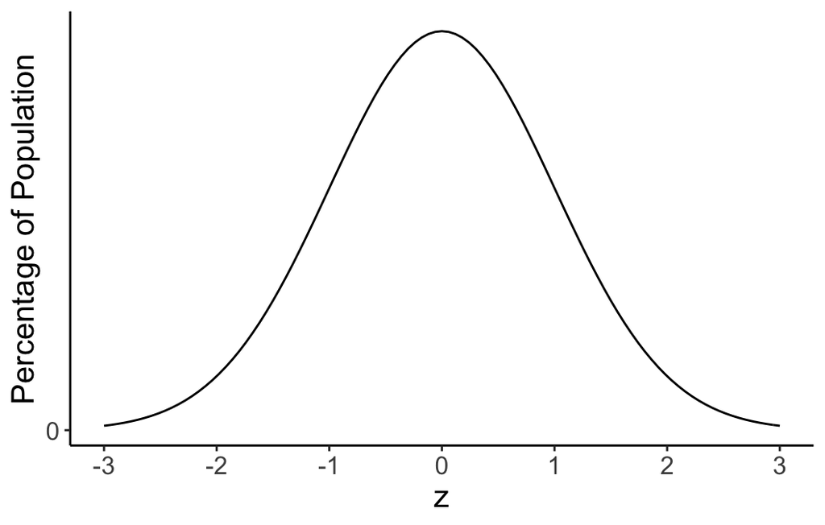

The normal distribution is a very common probability distribution

- Also known as a Gaussian distribution or “bell curve”
- Many variables are normally distributed (e.g., height, weight, IQ)
- We can use it to make inferences about unknown variables

## Inferential Statistics

### Normal Distribution

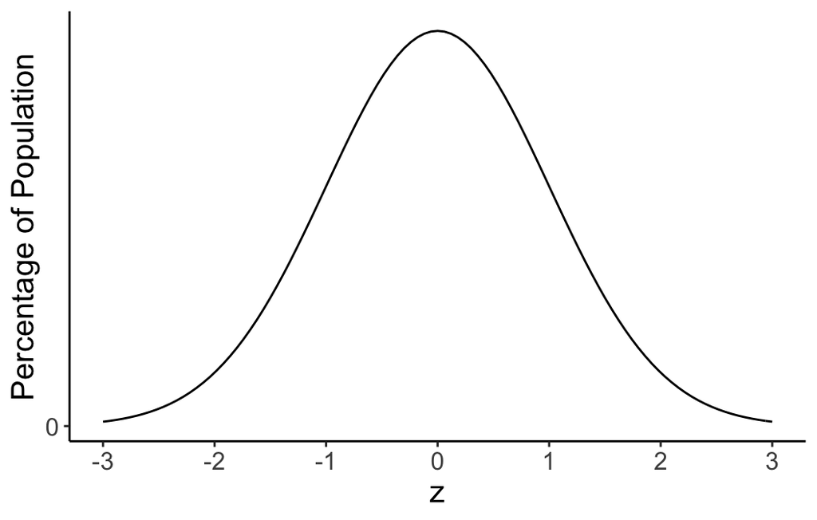

Any normal distribution can be described by two parameters:

## Inferential Statistics

### Normal Distribution

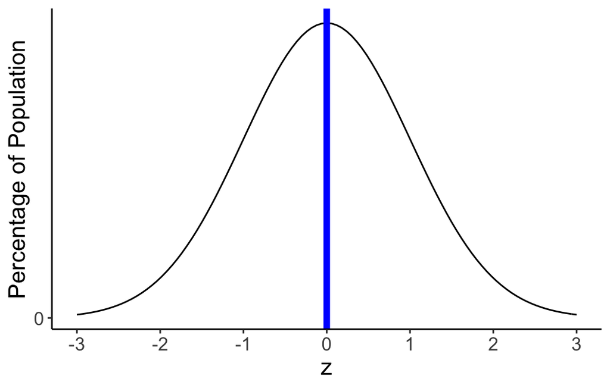

Any normal distribution can be described by two parameters:

- The **mean** indicates where the peak of the distribution is located

## Inferential Statistics

### Normal Distribution

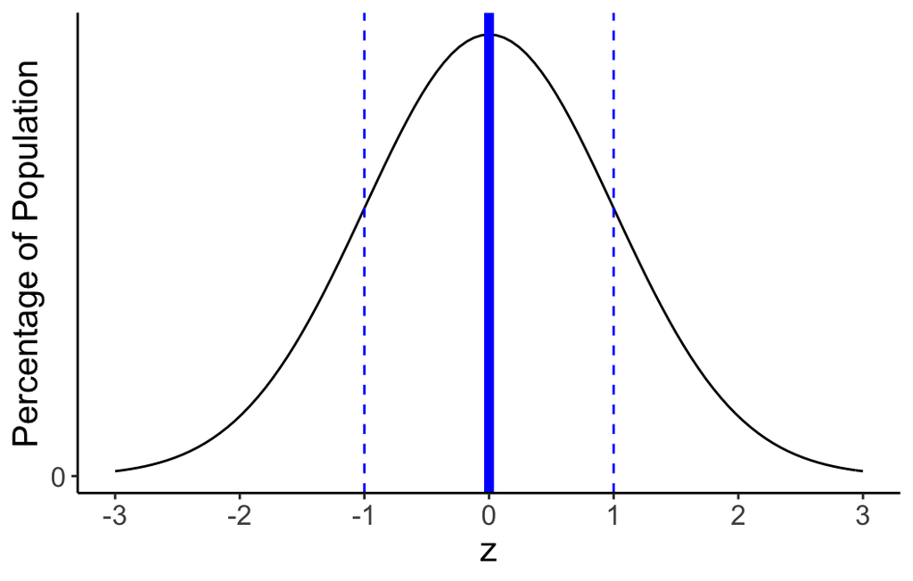

Any normal distribution can be described by two parameters:

- The **mean** indicates where the peak of the distribution is located
- The **standard deviation** indicates the typical distance between any given point and the mean

## Inferential Statistics

### z-Scores

A *z*-score indicates the number of standard deviations between a particular observation and the mean.

\[z = \frac{value - mean}{SD}\]

## Transforming z-Scores into Percentiles

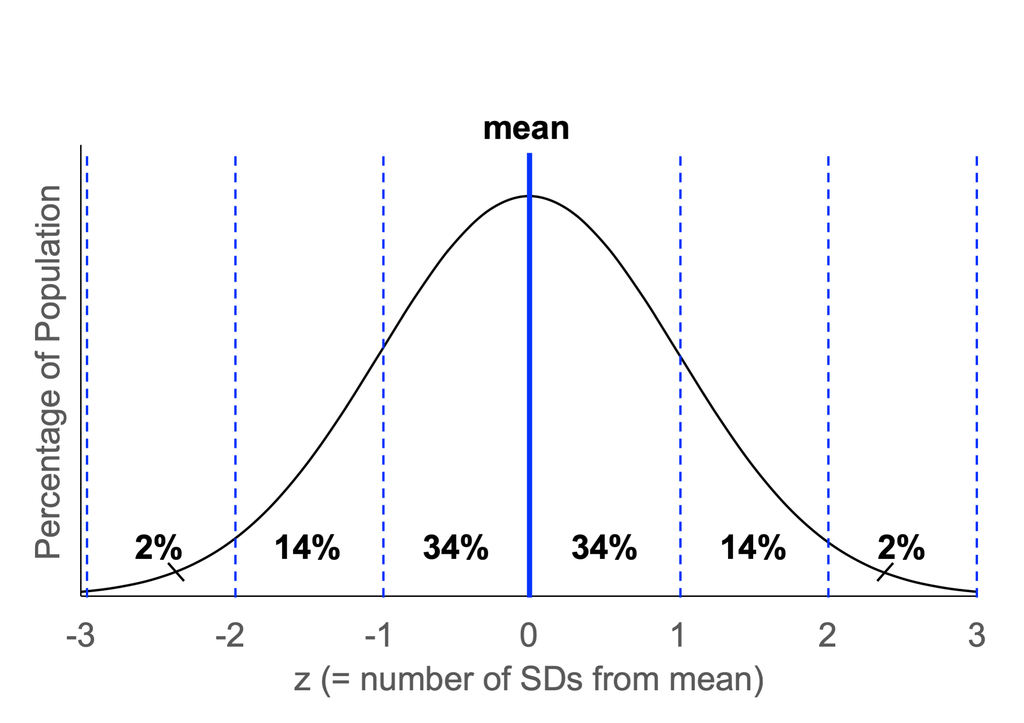

## Transforming z-Scores into Percentiles

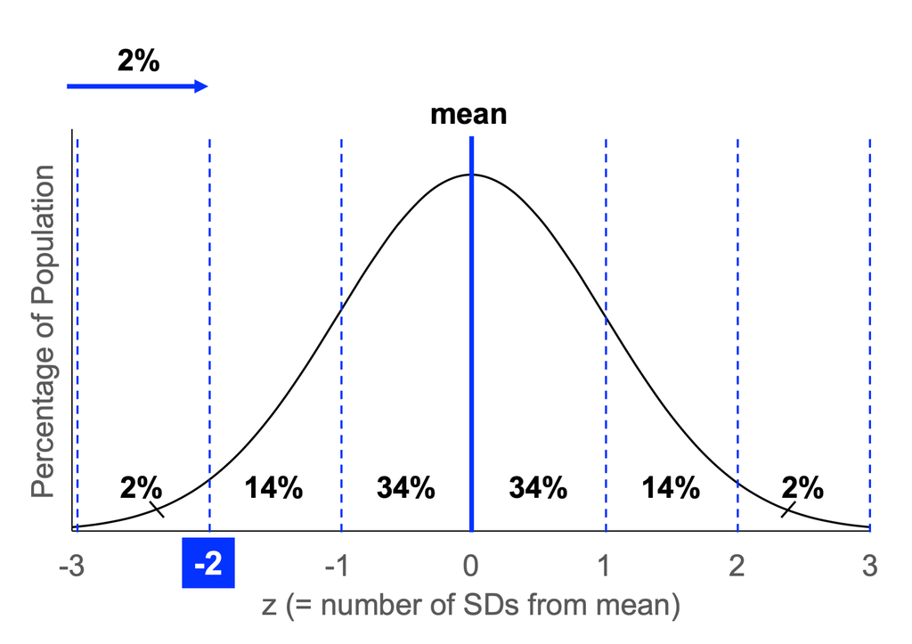

## Transforming z-Scores into Percentiles

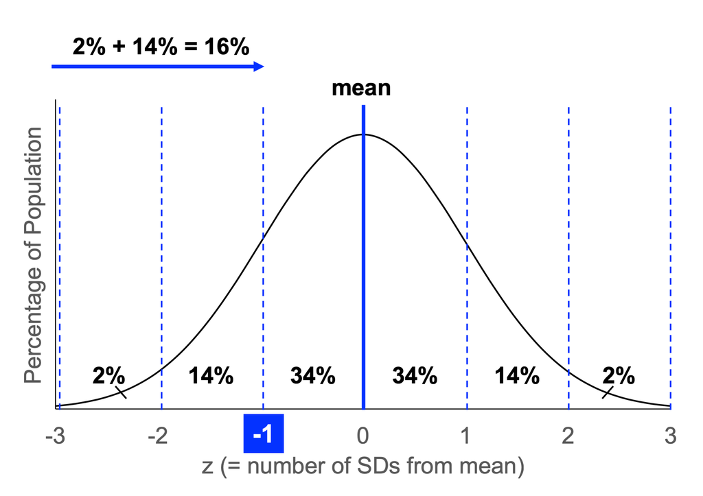

## Transforming z-Scores into Percentiles

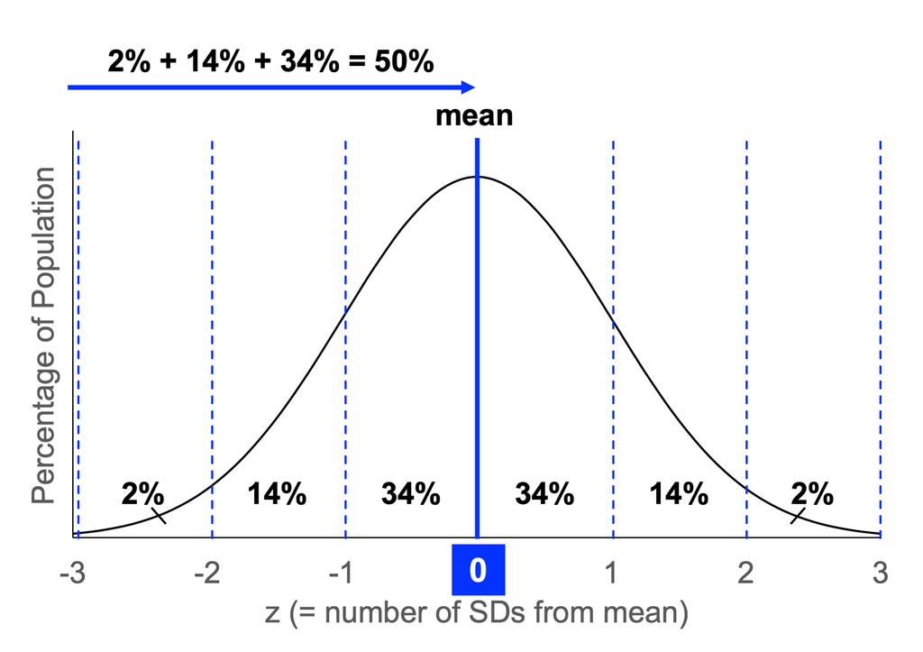

## Transforming z-Scores into Percentiles

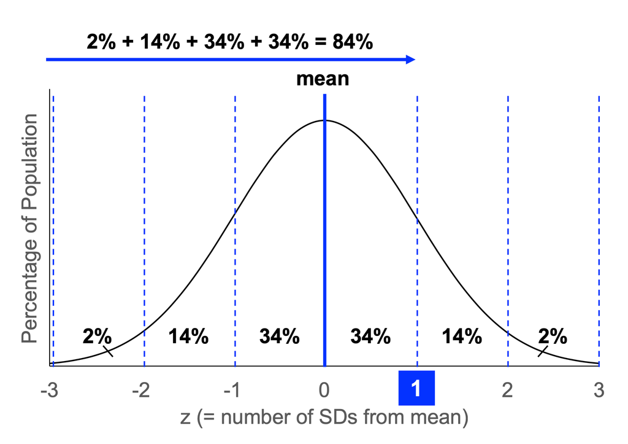

## Transforming z-Scores into Percentiles

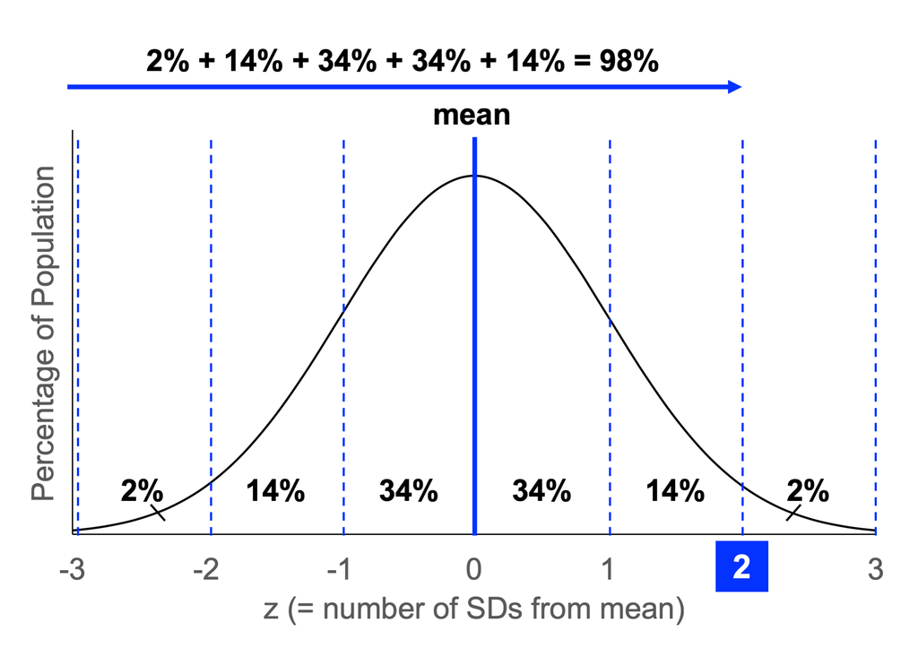

## Transforming z-Scores into Percentiles

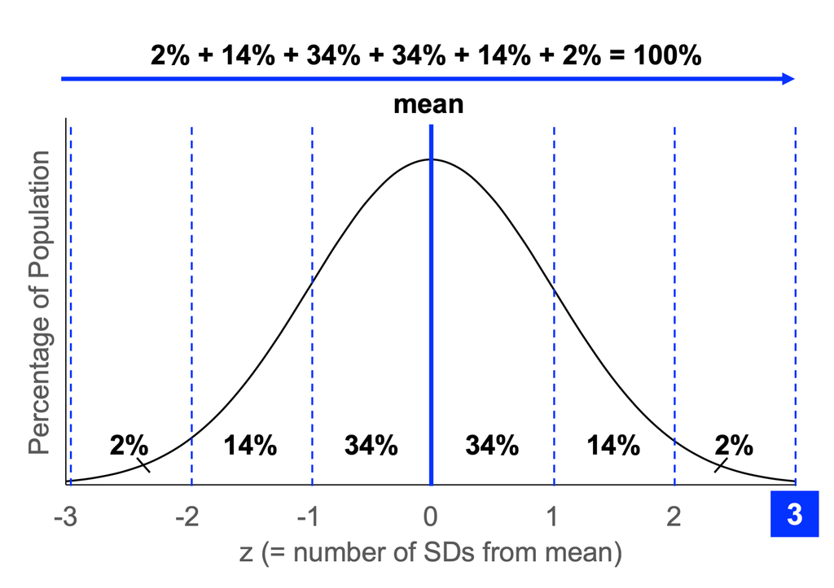

## Transforming z-Scores into Percentiles

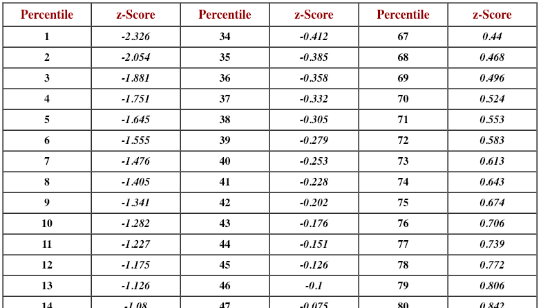

https://www.pindling.org/Math/Learning/Statistics/z_scores_table.htm

## Big Five Inventory

### John, Donahue, & Kentle, 1991

- Extraversion: assertive, full of energy, talkative
- Agreeableness: sympathetic, affectionate, kind
- Conscientiousness: planful, thorough, organized
- Neuroticism: anxious, tense
- Openness to experience: curious, imaginative, interested in a range of topics

## Big Five Inventory: Extraversion

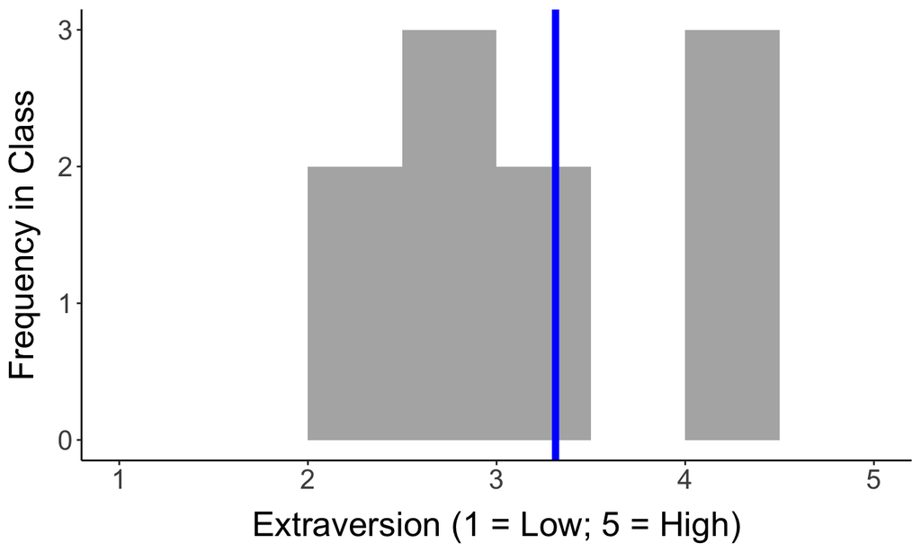

- Mean: 3.31
- SD: 0.76

## Big Five Inventory: Agreeableness

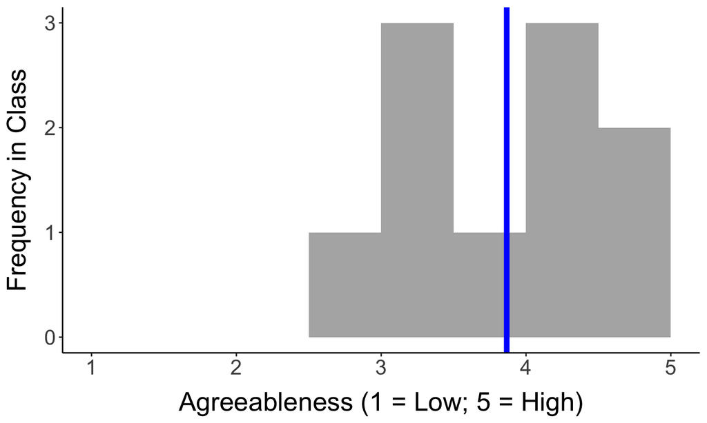

- Mean: 3.87
- SD: 0.7

## Big Five Inventory: Conscientiousness

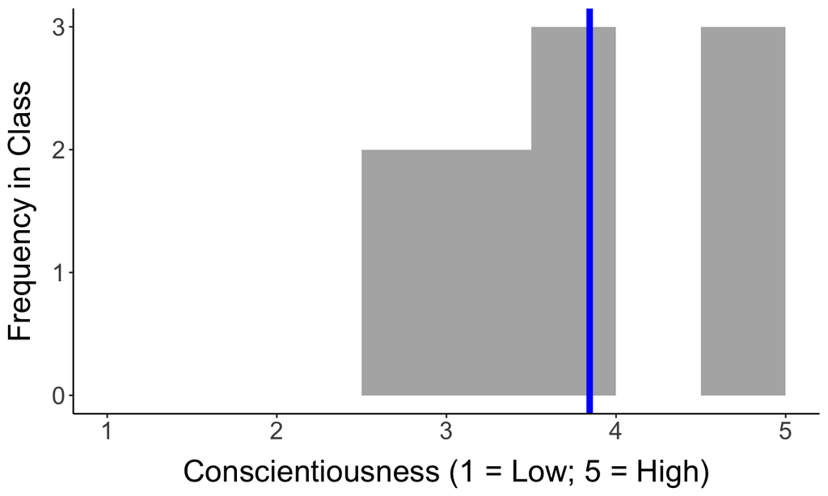

- Mean: 3.84
- SD: 0.69

## Big Five Inventory: Neuroticism

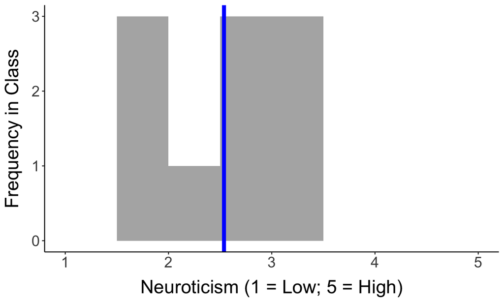

- Mean: 2.54
- SD: 0.57

## Big Five Inventory: Opennness to Experience

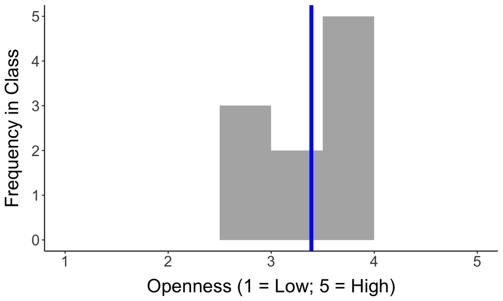

- Mean: 3.39
- SD: 0.53

## Regulatory Focus Questionnaire

### Higgins et al., 2001

- Prevention pride: historical success in maintaining security and fulfilling responsibilities; approach new goals vigilantly
- Promotion pride: historical success in achieving hopes and aspirations; approach new goals eagerly

## Regulatory Focus Questionnaire

### Higgins et al., 2001

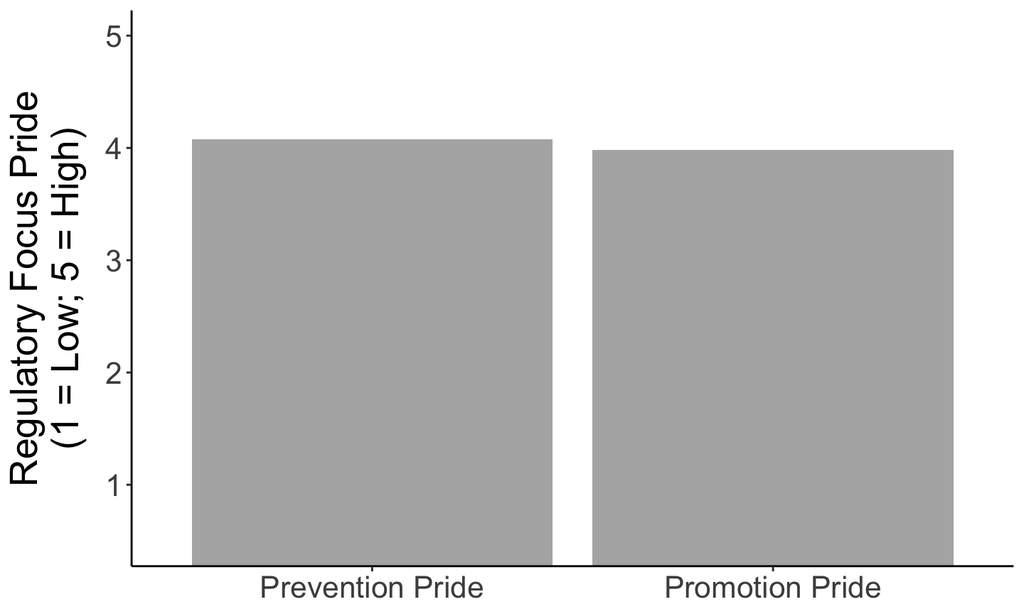

- Prevention Mean: 4.08 (SD = 0.73)
- Promotion Mean: 3.98 (SD = 0.48)

## Regulatory Mode Questionnaire

### Kruglanski et al., 2000

- Assessment: oriented toward thinking and critical evaluation in goal pursuit
- Locomotion: oriented toward doing, movement, and action in goal pursuit

## Regulatory Mode Questionnaire

### Kruglanski et al., 2000

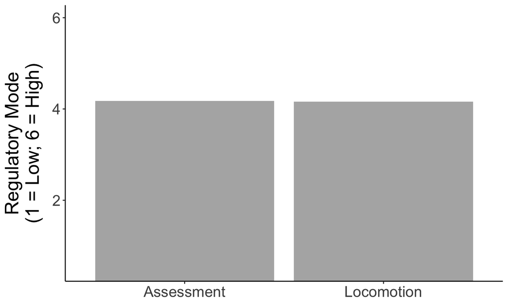

- Assessment Mean: 4.17 (SD = 0.93)
- Locomotion Mean: 4.16 (SD = 0.74)

## Moral Foundations Questionnaire

### Graham, Haidt, & Nosek, 2008

- Care/Harm: kindness, compassion, nurturance
- Fairness/Cheating: justice, equality
- Loyalty/Betrayal: patriotism, ingroup loyalty
- Authority/Subversion: authority, respect for traditions
- Sanctity/Degradation: purity, chastity, avoidance of disgusting behavior

## Moral Foundations Questionnaire

### Graham, Haidt, & Nosek, 2008

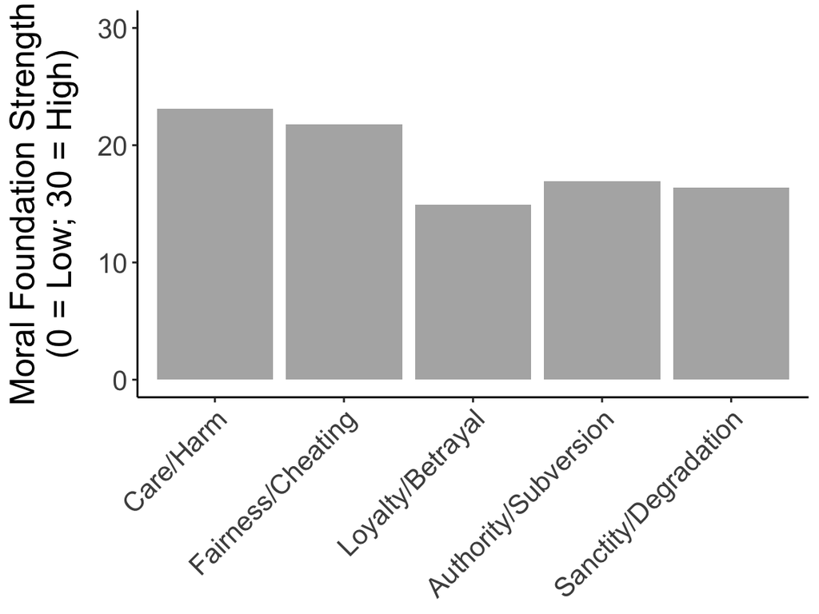

- Care/Harm Mean: 23.1 (SD = 3.9)
- Fairness/Cheating Mean: 21.8 (SD = 3.39)
- Loyalty/Betrayal Mean: 14.9 (SD = 5.17)
- Authority/Subversion Mean: 16.9 (SD = 5.22)
- Sanctity/Degradation Mean: 16.4 (SD = 6.2)

## Relationship Theories Questionnaire

### Franiuk, Cohen, & Pomerantz, 2002

- Soulmate theories: relationship satisfaction depends upon finding the right person
- Work-it-out theories: relationship satisfaction depends upon putting effort into the relationship

## Relationship Theories Questionnaire

### Franiuk, Cohen, & Pomerantz, 2002

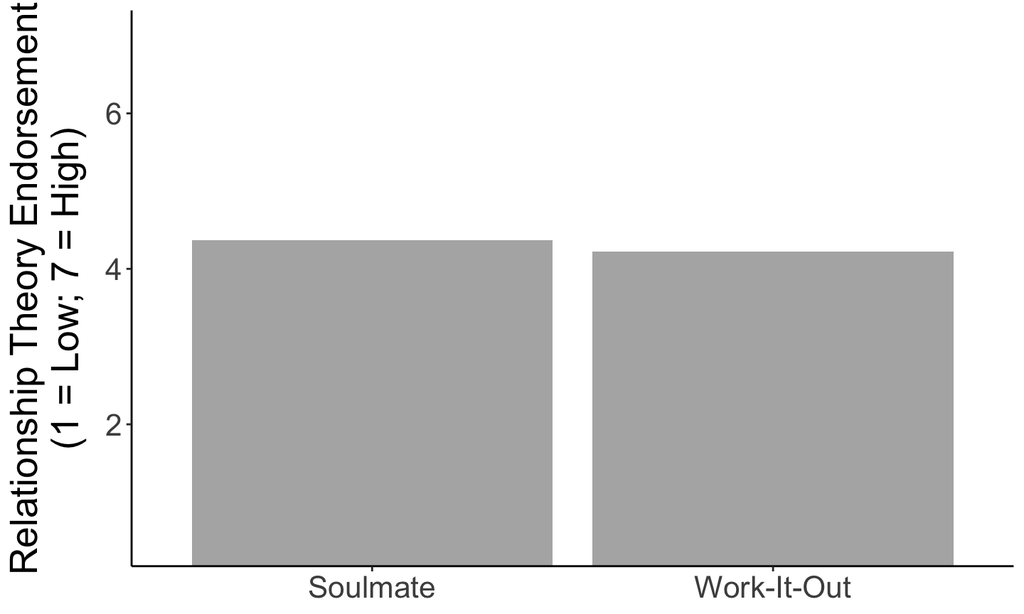

- Soulmate Mean: 4.37 (SD = 0.68)
- Work-It-Out Mean: 4.22 (SD = 1.26)

## Aspiration Index

### Kasser & Ryan, 1996

- Intrinsic: fulfill fundamental needs
  - Self-acceptance
  - Affiliation
  - Feeling that one is part of a community
  - Physical fitness
- Extrinsic: means to some other end
  - Financial success
  - Attractive appearance
  - Social recognition

## Aspiration Index

### Kasser & Ryan, 1996

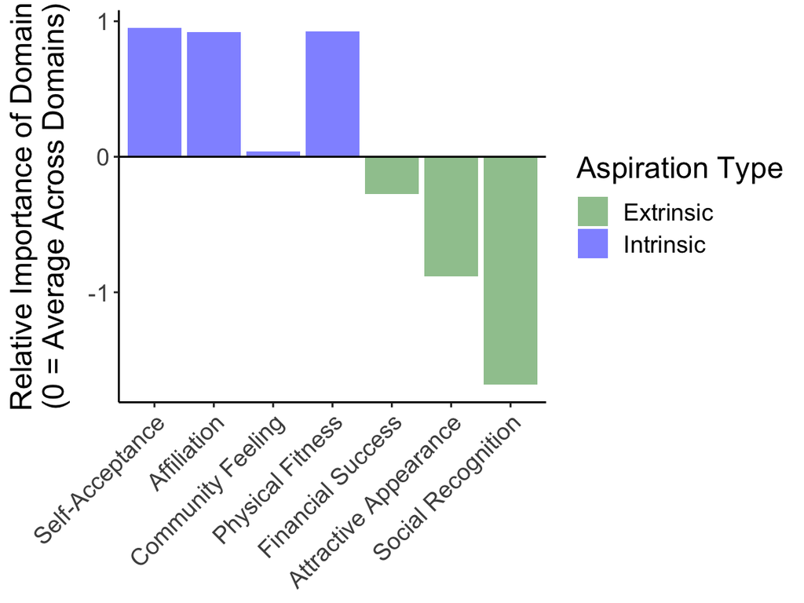

- Self-Acceptance: 0.95
- Affiliation: 0.92
- Community Feeling: 0.04
- Physical Fitness: 0.92
- Financial Success: -0.27
- Attractive Appearance: -0.88
- Social Recognition: -1.68

## Preference Measures

### Beach or Mountain?

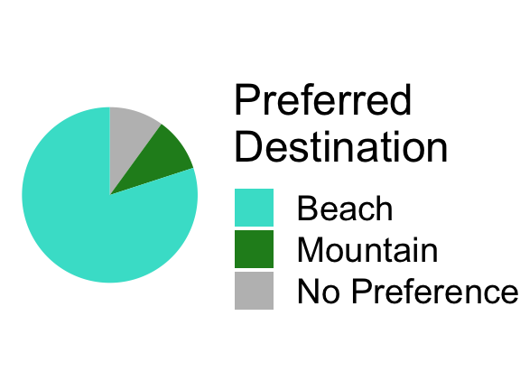

- Beach: 80%
- Mountain: 10%

### Cat or Dog?

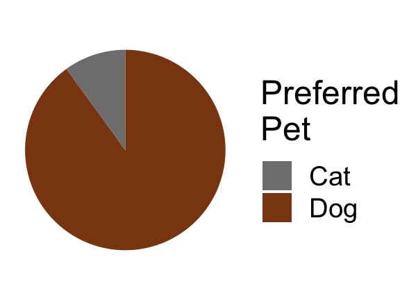

- Cat: 10%
- Dog: 90%

### Coffee or Tea?

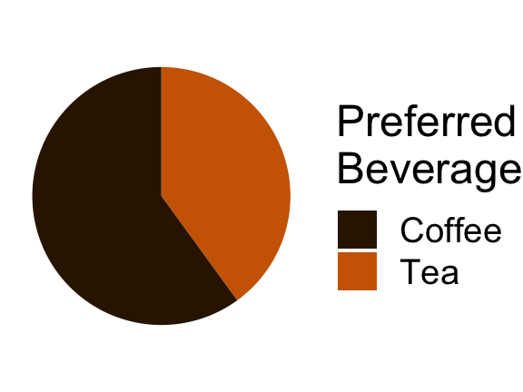

- Coffee: 60%
- Tea: 40%

## In-Class Reflection

- Download Word document from Assignments tab on Canvas
- Complete responses within the document:
  1. What did you learn about yourself that you didn’t already know? (20 pts)
  2. What did you think was accurate? What was inaccurate? (20 pts)
  3. How could these measurements be improved? Why? (Justify your answer.) (10 pts)
- Formatting requirements:
  - Maximum of 3 pages, double-spaced, Times New Roman 12 pt., 1" margins
  - Filename: FirstnameLastname_UNI.docx (e.g., EmilyNakkawita_ebn2111.docx)
- Submit on Canvas by the end of the class period